# Analysis of the Nutrition, Physical Activity, and Obesity Dataset by the Centers for Disease Control and Prevention (CDC)

Devon Smith

2025-03-29

# (i) Introduction

For my project, I am going to look into the ‘Nutrition, Physical Activity, and Obesity’ dataset that is provided publicly by the CDC.

I hope to be able to answer many questions about Health and Fitness in the United States. I will include how obesity rates / physical activity rates have changed over the past 12 years (2011-2023). It will be extremely interesting to learn about our health and wellness in the United States, as our personal well-being is a major factor in other metrics of the country’s performance.

I am interested in this topic because Health and Fitness has become an important part of my life, as I have played on a club’s sports team throughout college and have worked on growing confidence in my body. As with any topic, I love to deepen my knowledge, and I find that data analysis is one of the most interesting ways to learn more.

# (ii) Data

This data comes from the Behavioral Risk Factor Surveillance System (BRFSS), which is a government program that completes telephone surveys across all 50 US States and territories, collecting data about people’s health and well being. The dataset currently only has data from 2011 through 2023.

This dataset contains over 20 columns and 104272 rows. It is an extremely valuable dataset often used by scientists and researchers to examine health/fitness in the United States. It contains variables including questions asked, percentage values, sex, states, coordinates, education, age, and year collected.

Most of my analysis is completed on the variable ‘Data_Value’. This variable is referenced by the variable ‘Question’, which gives context of it’s meaning. For example, for the question “percent of adults aged 18 years and older who have obesity”, ‘Data Value’ gives the metric to measure that question, between 1 and 100 percent.

### Data Cleaning

Data Cleaning is performed to make the data ‘tidy’ for analysis. Most real data is often extremely messy to perform analysis on, so I completed the following steps to make this dataset more efficent for analysis:

-Lowercase everything

-Separate Both Age and Income to Upper / Lower Bounds (and remove symbols)

-Address Null Values (explained below)

When deciding what to do with the missing values, I won’t be able to delete the rows with missing variables as the entire dataset will be left with no observations, as every row is missing at least one observation.

Therefore, I have decided to replace all instances of NA’s with the median value for that column. I chose the median over the mean due to the distribution visualizations below, as well as the summary statistics for median/mean below, as some of the distributions are heavily skewed. Choosing the median allows a value that is not skewed by outliers in the data.

# (iii) Basic Descriptive Information

Looking at the Mean (Average) Values for each numeric column in the dataset.

```
##   yearstart  yearend data_value_unit data_value data_value_alt
## 1  2017.006 2017.006        2016.017   31.83394       31.83394
##   low_confidence_limit high_confidence_limit sample_size age_lower_bound
## 1             27.43705              36.77173    3360.961        40.10714
##   age_upper_bound income_lower_bound income_upper_bound locationid
## 1              44              31250           43034.71   31.05371
```

Looking at the Median (Middle) Values for each numeric column in the dataset.

```
##   yearstart yearend data_value_unit data_value data_value_alt
## 1      2017    2017            2016       31.7           31.7
##   low_confidence_limit high_confidence_limit sample_size age_lower_bound
## 1                 27.3                  36.5        1085              40
##   age_upper_bound income_lower_bound income_upper_bound locationid
## 1              44              30000              42499         30
```

```
## For the BFRSS, the data started being collected in 2011 and has most recently been collected in 2023 . The data has been collected for the past 12 years.
```

In order to determine how I handle null values in this dataset, I must visualize the distributions of each variable. If the shape is a normal bell curve, I can comfortably use the mean, but if it is heavily skewed, I will use the median as the mean can be pulled by a skewed dataset.

As stated above, I chose to use the median for the numeric variables, as there were many skewed distributions.

For the categorical distributions below, I chose to replace null values with the word ‘Missing’, to communicate better in the graphs what the missing data is.

I used these visualizations to help me make these decisions, as well as get a better understanding of the dataset as a whole.

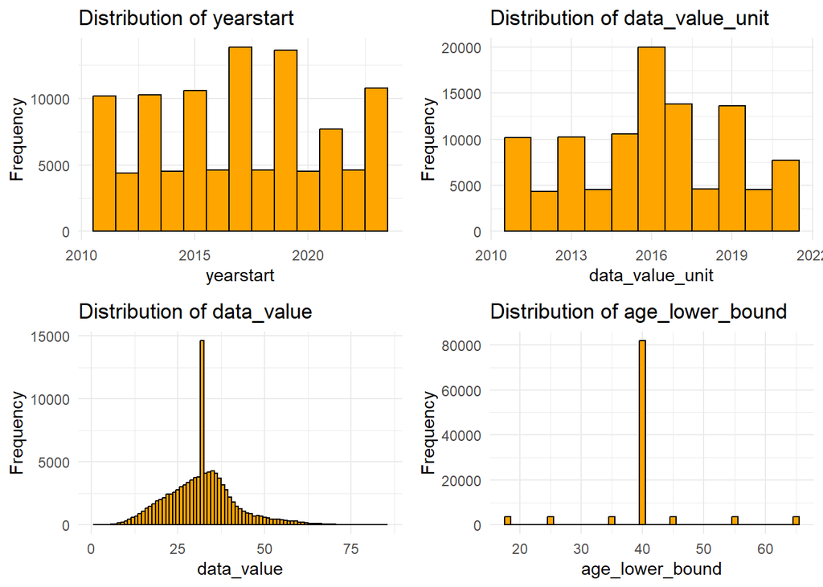

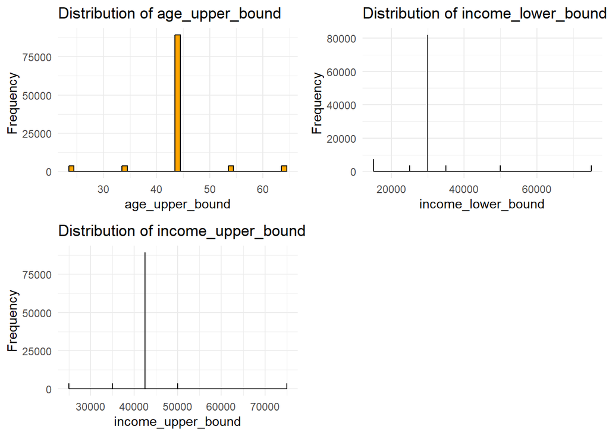

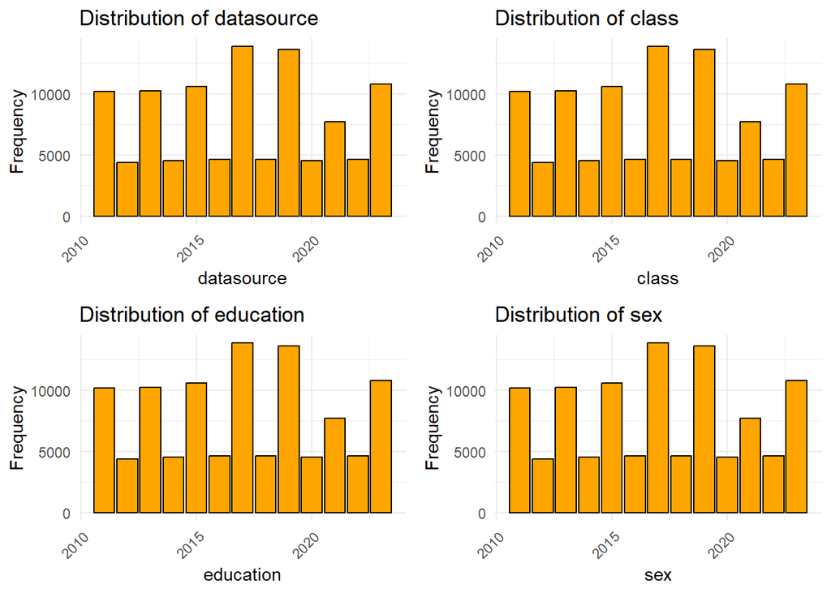

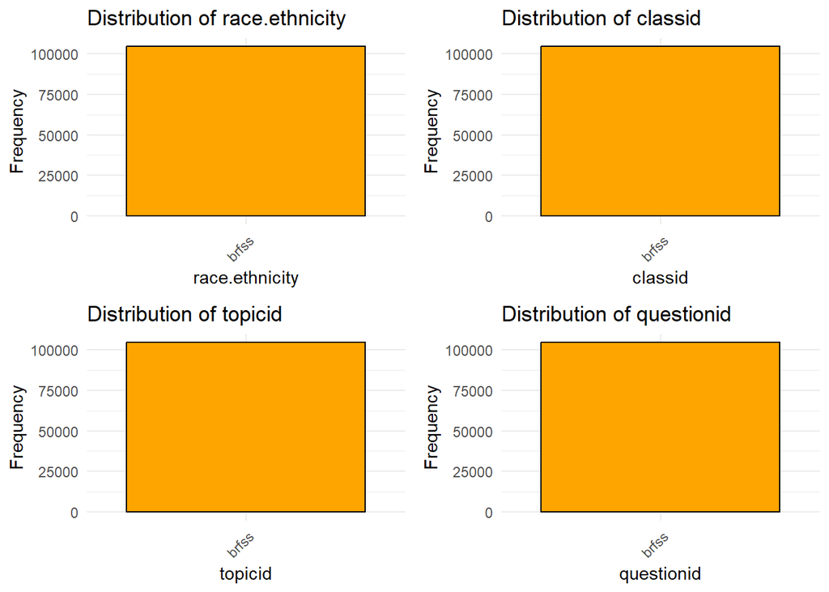

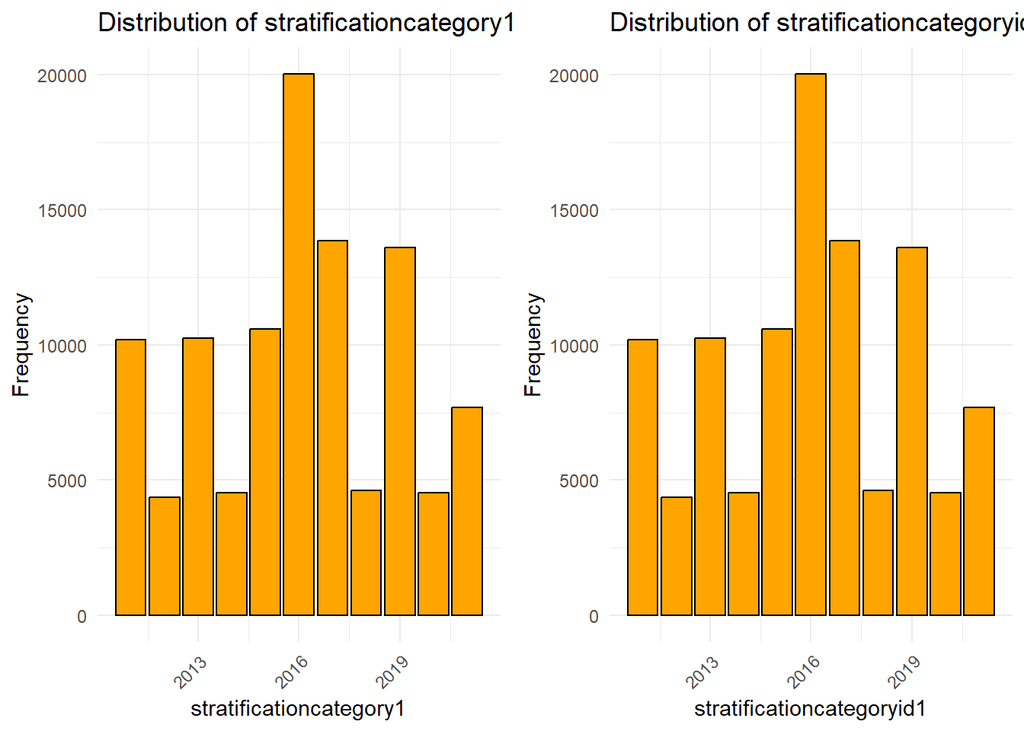

While there are many observations I have made from these summary graphs, I wanted to point out a few important ones:

- I will not consider factors such as sex, age, or demographics in my analysis, as most of the data for these variables are missing. In other statistical projects, there are methods to estimate / delete rows to keep it simplier. For the purpose of my project, I am looking at the United States as a whole, so I will simply not use these variables in my further analysis, as I am mostly focused on overall US performance / performance of the states.
- A total of 10 different questions were asked among 3 classes of questions, all measuring obesity, physical fitness, and nutrition in the United States. For this analysis, I am only choosing one subquestion per topic.
- All of the data has been contributed to by the BRFSS, which lets us know that the sole source of data is authored by the CDC.

# (iv) Analysis 1

Analysis 1: Checking the Relationship between Obesity and Time (2011-2023) using a bar plot.

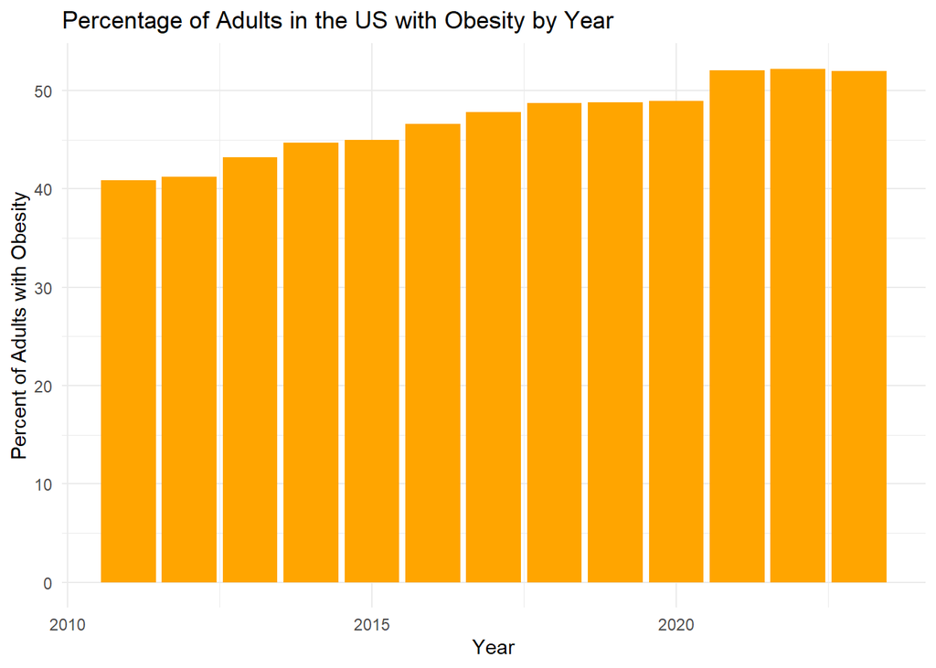

Based on the data, it seems obesity has steadily increased over the past 12 years in the United States. In 2011, the percentage of US Adults with obesity was a little over 40%, which has risen to over 50% most recently in 2023.

While most of the data regarding the age of the respondents of this dataset is null, it is important to consider that this dataset may mostly contain people of a certain age group. If the BRFSS mainly went out to members of an older age group, than this dataset would reflect the older population in the US.

# (v) Analysis 2

Analysis 2: Checking the Relationship between Physical Activity and Time (2011-2023) using a bar plot.

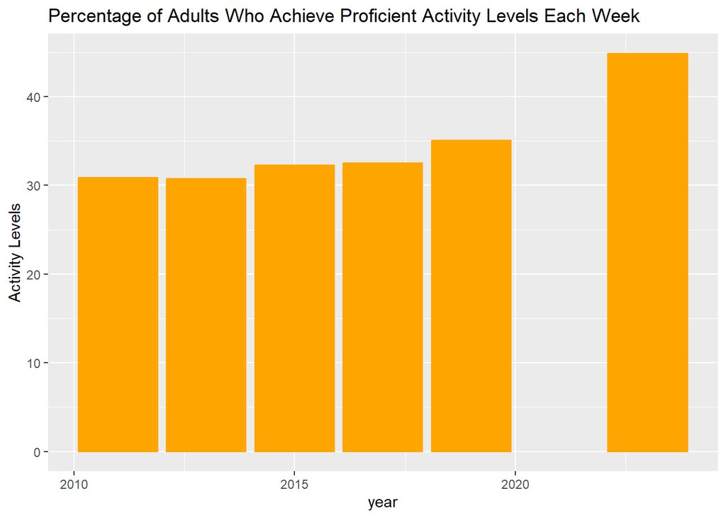

Based on the data, it seems that physical activity across all 50 states has increased over the past 12 years. There is a gap during the years on 2020 and 2021, which could potentially be due to the covid-19 pandemic. Physical activity spiked in the most recent year published as well, which could be due to other cofounding variables.

I personally found this result especially interesting, as obesity / physical activity have a inverse relationship in the current existing academic literature.

# (vi) Analysis 3

Analysis 3: Checking the Relationship between Fruit/Vegetable Consumption by State, via a map of the United States.

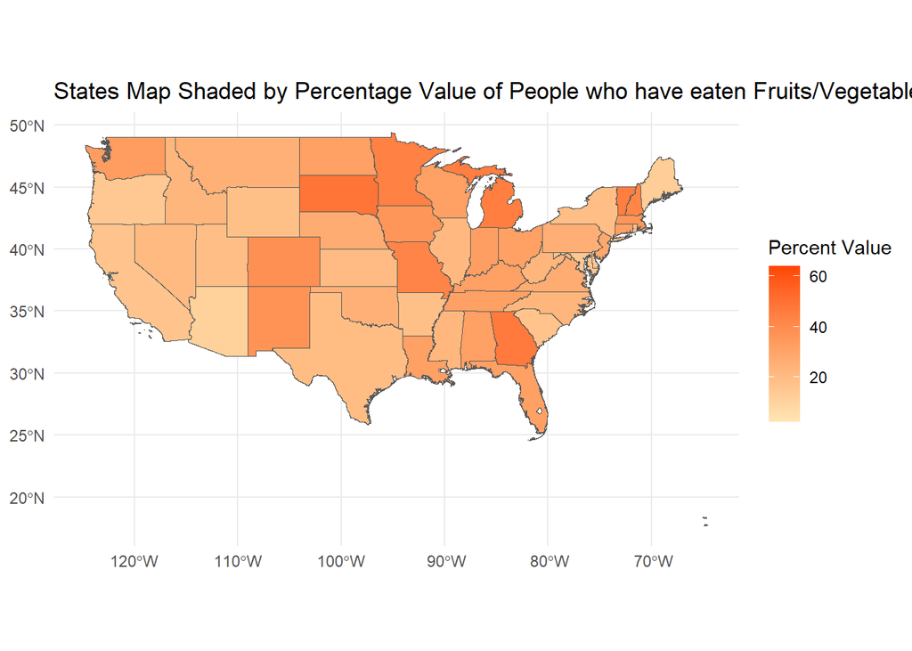

```
## List of 1
##  $ legend.position: chr "right"
##  - attr(*, "class")= chr [1:2] "theme" "gg"
##  - attr(*, "complete")= logi FALSE
##  - attr(*, "validate")= logi TRUE
```

Based on this graph of the United States, most states seem to have under 40% of their populations eat at least one fruit or vegetable per day. This could be a factor in explaining why obesity has risen over the past 12 year, but I am not able to make a conclusion without further statistical analysis.

# (vii) Conclusions

The purpose of this analysis was to investigate the different relationships between Nutrition, Obesity, Fitness, and Time in the United States, to assess our progress as a country towards healthier lifestyles.

This analysis highlighted that Obesity Rates seem to be rising in the United States while Physical Activity Rates seem to be increasing as well. This positive correlation suggests confounding variables such as nutrition, due to the well-defined inverse relationship between obesity and physical activity in the existing academic literature.

This assumption became more relevant in the third analysis, which showed that the majority of the United States eats less than one fruit / vegetable per day, on average. This highlights the importance of research on nutrition specifically in the United States, and the importance of ensuring more people are able to access these vital food groups.

### Sources

-Shapefiles from https://www.weather.gov/gis/USStates

-Data from https://data.cdc.gov/Nutrition-Physical-Activity-and-Obesity/Nutrition-Physical-Activity-and-Obesity-Behavioral/hn4x-zwk7/about_data